# STAT 440 Statistical Data Management - Spring 2022

## Week02 Practice Lab00 Fri

### Both .Rmd and .html files must be submitted by 11:00 am. Any lab submitted after 11:00 am will be deducted 2 points for being late. Labs submitted after the lab solution is posted will not be accepted; resulting in a 0 for that driver’s lab.

#### Only the driver should submit this assignment into their individual student repo. Save the filename as lab00-week02-fri-netID.Rmd and render this file to .html.

**#1** (Syllabus, Markdown) Using Markdown syntax, make a numbered list with the names of everyone at your station in all caps. Your name should appear in all lower case text.

**Answer:** Answers will vary, but driver’s name must be in lower case text and passengers names’ in all caps.

1. chris kinson
2. OTHER PASSENGERS

**#2** (Syllabus, Markdown) Who are the TAs? Write the names of the TAs as an unordered list.

**Answer:**

- Jaideep Mahajan
- Jim (or Yici) Yan

**#3** (Git/GitHub, Markdown) In which of the following cases is the file name in bold **Homework01Kinson2** written?

1. pascal case
2. snake case
3. camel case
4. kebab case

**Answer:** The case is a. pascal case.

**#4** (Accessing and importing data) Import the members of the current US Congress Data using its and the data URL https://theunitedstates.io/congress-legislators/legislators-current.json and print its structure. This structure should match the data description below.

- The dataset (a .json file) contains the 540 members of the US Congress with 6 variables (or “columns”) per person which includes details about the legislators’ first and last names, official full name, middle name, nickname, and suffixes. According to the GovTrack, “the United States Congress has two chambers, one called the Senate and the other called the House of Representatives (or”House” for short) which share the responsibilities of the legislative process to create federal statutory law.” The original source is GovTrack.

**Answer:**

```r
library(tidyverse)
library(jsonlite)
congress0 <- fromJSON("https://theunitedstates.io/congress-legislators/legislators-current.json")
congress <- congress0[[2]]
str(congress)
```

```
## 'data.frame':    540 obs. of  6 variables:
##  $ first        : chr  "Sherrod" "Maria" "Benjamin" "Thomas" ...
##  $ last         : chr  "Brown" "Cantwell" "Cardin" "Carper" ...
##  $ official_full: chr  "Sherrod Brown" "Maria Cantwell" "Benjamin L. Cardin" "Thomas R. Carper" ...
##  $ middle       : chr  NA NA "L." "Richard" ...
##  $ nickname     : chr  NA NA NA NA ...
##  $ suffix       : chr  NA NA NA NA ...
```

**#5** (Syllabus, Markdown) At your station, there is a puzzle. Solve and complete the puzzle and take a picture of the finished puzzle. Using Markdown syntax, include the picture (using a hyperlink) as the solution to this problem.

**Answer:** Pictures will vary but must be linked using Markdown syntax such as

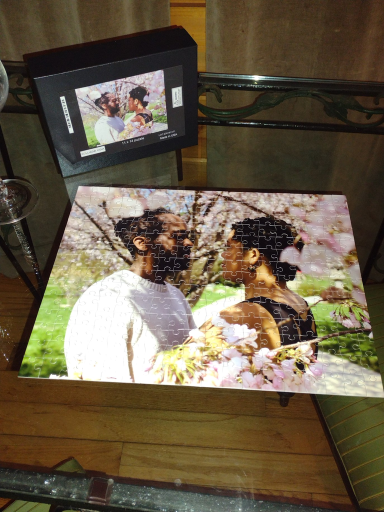